# intro_to_nlp slides

## Introduction to NLP

We will cover *practical* NLP:

- how to process text
- how to do useful things with it

... we will not cover *theoretical* NLP:

- grammars, syntax, linguistic models
- (sorry Noam)

# Why NLP?

[figure not shown]

[1] [CS224N](http://web.stanford.edu/class/cs224n/)

# Why is NLP hard?

[figure not shown]

# Why is NLP hard?

[figure not shown]

[Garden-path sentence (wiki)](https://en.wikipedia.org/wiki/Garden-path_sentence) / [Crash Blossoms](https://languagelog.ldc.upenn.edu/nll/?cat=118)

# Why is NLP hard?

- ambiguous
- complex
- context dependent
- requires prior knowledge
- requires a world model
- is used for interaction with people (amusing, insulting)

## Famous NLP successes

- GPT-3
- [Google Translate](https://en.wikipedia.org/wiki/Google_Neural_Machine_Translation)
- [AI Dungeon](https://play.aidungeon.io/)
- [DALL-E](https://openai.com/blog/dall-e/)

# Words as data

Let's start with some very short reviews, and our goal is to classify whether they are positive (1) or negative (0) in terms of *sentiment*, i.e. whether someone liked the movie or not.

```python
sentences = [
    'We had a good time.',
    'This was a good-looking place.',
    'A once in a lifetime experience.',
    'Horrible.',
    'One of the worst experiences of my life.',
    "Everything went terribly, I'll never return."
]
y = [1, 1, 1, 0, 0, 0]
```

## Create a feature matrix

- We need to transform `sentence` into a matrix of features (`X`)
- < w<sub>1</sub>, w<sub>2</sub>, ..., w<sub>M</sub> > -> **x**<sub>i</sub>
- How would you do this?

## A silly approach

We can memorize the sentences, and output the known answer.

```python
# create a dictionary which maps each sentence to a known outcome
model = {sentences[i]: y[i] for i in range(len(sentences))}
print('Model')
for sentence, target in model.items():
    print(f'  {sentence}: {target}')


# see how often our model is correct
print('\nPerformance')
match = [model[sentence] == y[i] for i, sentence in enumerate(sentences)]
print(f'{sum(match) / len(sentences):3.1%} accuracy.')
```

```
Model
  We had a good time.: 1
  This was a good-looking place.: 1
  A once in a lifetime experience.: 1
  Horrible.: 0
  One of the worst experiences of my life.: 0
  Everything went terribly, I'll never return.: 0

Performance
100.0% accuracy.
```

# What if we try a new sentence?

```python
sentence = ""
target = 0
```

```python
sentences_test = [
    'This was fun!',
    'Abysmal service.'
]
y_test = [1, 0]

try:
    match = [model[sentence] == y[i] for i, sentence in enumerate(sentences_test)]
    print(f'{sum(match) / len(sentences_test):3.1%} accuracy.')
except KeyError as err:
    print(f'Sentence not found in model!')
```

```
Sentence not found in model!
```

Here is the traceback for the error we would have had without the try/except block:

```
---------------------------------------------------------------------------
KeyError                                  Traceback (most recent call last)
<ipython-input-5-1d2b9ac74b7f> in <module>
----> 1 match = [model[sentence] == y[i] for i, sentence in enumerate(sentences_test)]
      2 print(f'{sum(match) / len(sentences_test):3.1%} accuracy.')

<ipython-input-5-1d2b9ac74b7f> in <listcomp>(.0)
----> 1 match = [model[sentence] == y[i] for i, sentence in enumerate(sentences_test)]
      2 print(f'{sum(match) / len(sentences_test):3.1%} accuracy.')

KeyError: 'This was fun!'
```

## Create a feature matrix

- We need to transform a `sentence` into a matrix of features (`X`).
- We can represent a `sentence` as a collection of symbols *s*

[s<sub>1</sub>, s<sub>2</sub>, ..., s<sub>M</sub>] *--->* [x<sub>1</sub>, x<sub>2</sub>, ..., x<sub>D</sub>]

Note D (length of **x**) != M (number of symbols in the sentence).

- How would you do this?

# A slightly less silly approach

One feature for every letter in the alphabet

| s<sub>1</sub> | s<sub>2</sub> | s<sub>3</sub> | s<sub>4</sub> |  | to |  | x<sub>1</sub> | x<sub>2</sub> |
| --- | --- | --- | --- | --- | --- | --- | --- | --- |
| d | i | p |  |  |  |  | 0 | 1 |
| c | a | t |  |  |  |  | 0 | 0 |
| h | i |  |  |  |  |  | 1 | 0 |
| s | h | i | p |  |  |  | 1 | 1 |

```python
alphabet='abcdefghijklmnopqrstuvwxyz'
def prepare_data(sentences, alphabet=alphabet):
    return [[int(a in sentence) for a in alphabet] for sentence in sentences]

X = prepare_data(sentences)
```

```python
# visualize the data with the sentence
print(alphabet)
for i, sentence_vector in enumerate(X):
    print(''.join([str(c) for c in sentence_vector]), end=' ')
    print(sentences[i])
```

```
abcdefghijklmnopqrstuvwxyz
10011011100010100001000000 We had a good time.
10111011101101110010001000 This was a good-looking place.
10101100100111110101000100 A once in a lifetime experience.
01001000100100100100000000 Horrible.
00101101100111110111001110 One of the worst experiences of my life.
01001011100101000101111010 Everything went terribly, I'll never return.
```

## Train the model

```python
mdl = tree.DecisionTreeClassifier(max_depth=3)

# fit the model to the data - trying to predict y from X
mdl = mdl.fit(X, y)
```

## Try our model on new data

```python
X_test = prepare_data(sentences_test)
pred_test = mdl.predict(X_test)

match = [pred_test[i] == y_test[i] for i, sentence in enumerate(sentences_test)]
print(f'{sum(match) / len(sentences_test):3.1%} accuracy.')
print([(pred_test[i], sentence) for i, sentence in enumerate(sentences_test)])
```

```
50.0% accuracy.
[(1, 'This was fun!'), (1, 'Abysmal service.')]
```

That's... bad. What happened?

## Visualize the trained model

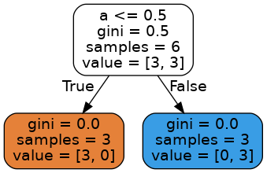

```python
graph = create_graph(mdl, feature_names=list(alphabet))
Image(graph.create_png())
```

```python
# print out the training set with the letter "a" highlighted in each sentence
for i, sentence in enumerate(sentences):
    sentence = ''.join([f"\033[1m\033[91m{c}\033[0m"  if c == 'a' else c for c in sentence])
    print(f'{sentence}: {y[i]}')
```

```
We had a good time.: 1
This was a good-looking place.: 1
A once in a lifetime experience.: 1
Horrible.: 0
One of the worst experiences of my life.: 0
Everything went terribly, I'll never return.: 0
```

# NLP has many levels

- Symbol/Character
- Lexeme
- Word
- Sentence
- *Paragraph*, *Document*, *Corpus*, ...

# NLP has many levels

- ~Symbol/Character~ - too low level (on its own!)
- ~Lexeme~ - we don't know what this means
- Word
- ~Sentence~ - too high level
- ~*Paragraph*, *Document*, *Corpus*, ...~ - same issue as sentences

# Words as data

- Our "alphabet" becomes all the words we've seen
  - Before: `alphabet = ['a', 'b', 'c', 'd', ...]`
  - Now: `alphabet = ['good', 'bad', 'movie', ...]`

```python
import itertools

# get all the unique words in the sentences, splitting by spaces
alphabet = sorted(list(set(
    [word for sentence in sentences
     for word in sentence.split(' ')]
)))
```

```python
print(alphabet)
```

```
['A', 'Everything', 'Horrible.', "I'll", 'One', 'This', 'We', 'a', 'experience.', 'experiences', 'good', 'good-looking', 'had', 'in', 'life.', 'lifetime', 'my', 'never', 'of', 'once', 'place.', 'return.', 'terribly,', 'the', 'time.', 'was', 'went', 'worst']
```

The above list.. isn't great.

- punctuation included in words
- "experience" and "experiences" separate
- "A" and "a" are different
- "good-looking" vs "good"

> Hrm, that's annoying.

*This should be the motto for NLP.*

# Words as data

- Focus on the word "good-looking".
- Should we split this into two words, "good" and "looking"?
- What about `I'll`? Strictly speaking, it's two words: `I` and `will`.

# Tokenization

- In NLP, we don't work with "words", we work with "tokens"
- *Tokens* are groups of symbols with some semantic meaning
- Tokenization is the process of converting text into individual tokens

# Tokenizers

- [spaCy's English tokenizer](https://spacy.io/api/tokenizer#_title)
- [nltk's English tokenizer](https://www.nltk.org/api/nltk.tokenize.html#module-nltk.tokenize)
- ... etc

# Trying it out

We'll work with spaCy's tokenizer.

```python
import spacy
# load an English spacy model we have already downloaded
nlp = spacy.load("en_core_web_sm")
```

# Trying it out

```python
for sentence in sentences:
    doc = nlp(sentence)
    print(sentence, end=': ')
    print([token for token in doc])
```

```
We had a good time.: [We, had, a, good, time, .]
This was a good-looking place.: [This, was, a, good, -, looking, place, .]
A once in a lifetime experience.: [A, once, in, a, lifetime, experience, .]
Horrible.: [Horrible, .]
One of the worst experiences of my life.: [One, of, the, worst, experiences, of, my, life, .]
Everything went terribly, I'll never return.: [Everything, went, terribly, ,, I, 'll, never, return, .]
```

# Trying it out

We can try other sentences to explore the tokenizer's quirks.

```python
sentence = "To be or not to be; that is the question. Or at least it was Hamlet's question."
doc = nlp(sentence)
print([token for token in doc])
```

```
[To, be, or, not, to, be, ;, that, is, the, question, ., Or, at, least, it, was, Hamlet, 's, question, .]
```

Rather than continue with the dummy dataset, let's get our hands on some real data.

# IMDb

A large dataset from the Internet Movie Database (IMDb) was curated by researchers [1].

- 50,000 reviews of movies on IMDB
- 25,000 positive reviews (>=7), 25,000 negative reviews (<=4)
- Commonly used for sentiment classification; i.e. is this review positive (great movie!) or negative (awful movie!)

> [1] Maas A, Daly RE, Pham PT, Huang D, Ng AY, Potts C. Learning word vectors for sentiment analysis. In Proceedings of the 49th annual meeting of the association for computational linguistics: Human language technologies 2011 Jun (pp. 142-150).

```python
def load_data(path):
    # initialize a dictionary (key-value store) for our corpus
    corpus = {}

    # for each file in the given folder path
    files = os.listdir(path)
    for fn in tqdm(files):
        filename = path / fn
        # open the file and read the text
        with open(filename, 'r') as fp:
            text = ''.join(fp.readlines())

        # put the text into the dictionary keyed by the filename
        # we can later access text data by indexing this dictionary
        # e.g. corpus["10_9"]
        corpus[filename.stem] = text

    return corpus

print('Loading positive documents (training set).')
pos = load_data(Path('aclImdb/train/pos'))
print('Loading negative documents (training set).')
neg = load_data(Path('aclImdb/train/neg'))

print('Loading positive documents (test set).')
pos_test = load_data(Path('aclImdb/test/pos'))
print('Loading negative documents (test set).')
neg_test = load_data(Path('aclImdb/test/neg'))

def get_numpy_arrays(pos, neg):
    # create numpy arrays of the datasets
    # these are more natively usable by ML libraries
    X_pos = np.array(list(pos.values()))
    X_neg = np.array(list(neg.values()))
    X = np.hstack([X_pos, X_neg])
    n_pos, n_neg = X_pos.shape[0], X_neg.shape[0]
    y = np.concatenate([np.ones(n_pos), np.zeros(n_neg)])
    return X, y

# only use ~1000 examples for speed
X_train, y_train = get_numpy_arrays(
    {k: v for k, v in pos.items() if k.startswith('2')},
    {k: v for k, v in neg.items() if k.startswith('2')}
)
X_test, y_test = get_numpy_arrays(
    {k: v for k, v in pos_test.items() if k.startswith('2')},
    {k: v for k, v in neg_test.items() if k.startswith('2')}
)
```

```
Loading positive documents (training set).
```

```
Loading negative documents (training set).
```

```
Loading positive documents (test set).
```

```
Loading negative documents (test set).
```

## Example review - [Stanley and Iris](https://www.imdb.com/title/tt0100680/?ref_=tt_urv)

[figure not shown]

## Example review - [Stanley and Iris](https://www.imdb.com/title/tt0100680/?ref_=tt_urv)

```python
review = pos['10_9']
print(review)
```

```
I'm a male, not given to women's movies, but this is really a well done special story. I have no personal love for Jane Fonda as a person but she does one Hell of a fine job, while DeNiro is his usual superb self. Everything is so well done: acting, directing, visuals, settings, photography, casting…
```

## Redo our character example with sklearn

With the mock dataset, we manually created the feature matrices with characters as features.

Now we'll use scikit-learn for modelling. Read more about the components of scikit-learn:

- Pipeline - compose operations commonly applied in ML
- [CountVectorizer](https://scikit-learn.org/stable/modules/generated/sklearn.feature_extraction.text.CountVectorizer.html) - convert text into features
- [User Guide on text feature extraction](https://scikit-learn.org/stable/modules/feature_extraction.html#text-feature-extraction) - a good intro into using scikit-learn for NLP
- [Decision Trees](https://scikit-learn.org/stable/modules/tree.html) - decision trees are a simple ML model - [colab tutorial on decision trees and more complex tree based models (e.g. xgboost)](https://colab.research.google.com/github/alistairewj/tree-prediction-tutorial/blob/master/trees-classification.ipynb)

## Build the model

```python
pipe = Pipeline([('vectorizer', CountVectorizer(
                    analyzer='char',
                    binary=True)
                 ),
                 ('classifier', tree.DecisionTreeClassifier(max_depth=3))])

# pipeline will be updated in-place!
pred = train_pipe_and_predict(pipe, X_train, y_train, X_test)

# Now that we have predictions for the test set (`pred`), we can calculate the performance of our model on a held out set.
print_results(y_test, pred)
```

```
Building model.
Getting test predictions.
Accuracy: 57.8%
Precision: 56.2%
Recall: 71.0%
```

## Visualize the model

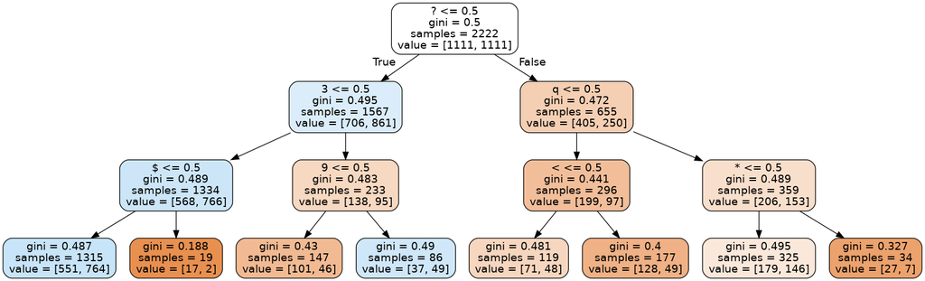

```python
# grab the vectorizer / classifier to make a figure of the model
vectorizer = pipe.named_steps['vectorizer']
classifier = pipe.named_steps['classifier']

graph = create_graph(classifier, feature_names=vectorizer.get_feature_names())
Image(graph.create_png())
```

Note that our `CountVectorizer` class has added symbols beyond the alphabet.

```python
print([c for c in sorted(list(vectorizer.vocabulary_.keys()))])
```

```
['\t', '\x10', ' ', '!', '"', '#', '$', '%', '&', "'", '(', ')', '*', '+', ',', '-', '.', '/', '0', '1', '2', '3', '4', '5', '6', '7', '8', '9', ':', ';', '<', '=', '>', '?', '@', '[', '\\', ']', '^', '_', '`', 'a', 'b', 'c', 'd', 'e', 'f', 'g', 'h', 'i', 'j', 'k', 'l', 'm', 'n', 'o', 'p', 'q', 'r',…
```

## Compare approaches

- Binary character presence: 57.8%.

## Count the characters rather than present/absent

In our above pipeline, we specified `binary=True`. From the [scikit-learn docs on CountVectorizer](https://scikit-learn.org/stable/modules/generated/sklearn.feature_extraction.text.CountVectorizer.html):

> binary **bool**, default=False

> If True, all non zero counts are set to 1. This is useful for discrete probabilistic models that model binary events rather than integer counts.

This creates what we had before - a feature matrix of 1s and 0s. As the name implies, `CountVectorizer` is able to return a matrix of counts for how often a character appears. We can see the impact of changing this below.

```python
pipe = Pipeline([('vectorizer', CountVectorizer(
                    analyzer='char',
                    binary=False)
                 ),
                 ('classifier', tree.DecisionTreeClassifier(max_depth=3))])

# pipeline will be updated in-place!
pred = train_pipe_and_predict(pipe, X_train, y_train, X_test)

# Now that we have predictions for the test set (`pred`), we can calculate the performance of our model on a held out set.
print_results(y_test, pred)
```

```
Building model.
Getting test predictions.
Accuracy: 55.4%
Precision: 53.6%
Recall: 81.2%
```

## Compare approaches

- Character presence: **57.8%**.
- Character counts: 55.4%.

# Recap

- We tried to classify some dummy text using the presence of letters
  - It did not go well
- We are going to try using the presence of words
  - We hope it will go better!

## Tokenize the review

```python
doc = nlp(review)
print([token for token in doc])
```

```
[I, 'm, a, male, ,, not, given, to, women, 's, movies, ,, but, this, is, really, a, well, done, special, story, ., I, have, no, personal, love, for, Jane, Fonda, as, a, person, but, she, does, one, Hell, of, a, fine, job, ,, while, DeNiro, is, his, usual, superb, self, ., Everything, is, so, well, d…
```

- `'m` and `'s` are given their own token
- punctuation marks are individual tokens
- whitespaces are individual tokens

As you can see, tokens *do not have to be words*!

... how do we turn this into `X`?

## Creating the feature matrix

- Recall when we used the alphabet
- Each column was a letter
- Each row was our sentence (now review)
  - `X[i,j] == 1` -> letter is in the document
  - `X[i,j] == 0` -> letter is **not** in the document
- We are using tokens instead of letters
  - **Advantage**: we think words will be a better representation of text meaning (compared to letters)
  - **Disadvantage**: we now need to create an "alphabet" for words, i.e. the **vocabulary**

# Vocabulary

- The set of tokens we choose is our *vocabulary*.
- Most vocabularies consist of the most common tokens.

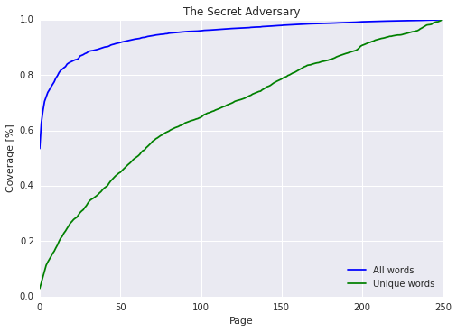

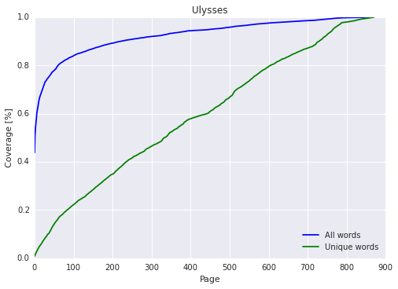

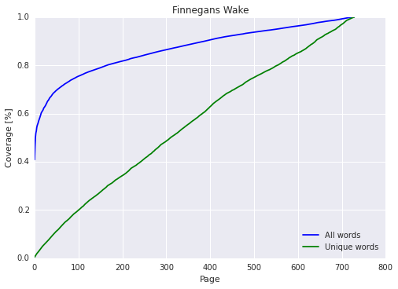

Source: [Book coverage by Roman Kierzkowski](https://github.com/vocapouch/vocapouch-research/blob/master/books/Book%20Coverage.ipynb)

```python
def spacy_tokenizer(text):
    return [token.text for token in nlp.tokenizer(text)]
```

```python
pipe = Pipeline([('vectorizer', CountVectorizer(tokenizer=spacy_tokenizer, max_features=10, binary=True)),
                 ('classifier', tree.DecisionTreeClassifier(max_depth=3))])

# pipeline will be updated in-place!
pred = train_pipe_and_predict(pipe, X_train, y_train, X_test)

# Model Accuracy
print_results(y_test, pred)
```

```
Building model.
Getting test predictions.
Accuracy: 49.5%
Precision: 49.7%
Recall: 90.9%
```

We now have 50% accuracy - no better than chance - yikes! What happened?

Well, we did select only the top 10 tokens (`max_features=10`). What do you think the top 10 tokens are in the IMDb dataset?

```python
from collections import Counter

token_freq = Counter()

for corpus in [pos, neg]:
    for text in tqdm(corpus.values(), total=len(corpus)):
        # only call the tokenizer for speed purposes
        doc = nlp.tokenizer(text)

        for token in doc:
            # use 'orth', the integer version of the string
            # will convert back to string version later
            token_freq[token.orth] += 1

# convert back to string
token_freq = Counter({nlp.vocab.strings[k]: v for k, v in token_freq.items()})
```

## The most popular word in each state

[figure not shown]

```python
token_freq.most_common(10)
```

```
[('the', 289838),
 (',', 275296),
 ('.', 236702),
 ('and', 156484),
 ('a', 156282),
 ('of', 144056),
 ('to', 133886),
 ('is', 109095),
 ('in', 87676),
 ('I', 77546)]
```

```python
text = pos['10_9']
print(text, end='\n\n')
freq = vectorizer.transform([text])[0].toarray()
features = vectorizer.get_feature_names()
for i, feat in enumerate(features):
    print(f'{feat:10s} {freq[0][i]:3d}')
```

```
I'm a male, not given to women's movies, but this is really a well done special story. I have no personal love for Jane Fonda as a person but she does one Hell of a fine job, while DeNiro is his usual superb self. Everything is so well done: acting, directing, visuals, settings, photography, casting…

	            0
            0
             1
!            0
"            0
#            0
$            0
%            0
&            0
'            1
(            0
)            0
*            0
+            0
,            1
-            1
.            1
/            0
0            0
1            0
2            0
3            0
4            0
5            0
6            0
7            0
8            0
9            0
:            1
;            0
<            0
=            0
>            0
?            0
@            0
[            0
\            0
]            0
```

[output cut: 48 more lines]

```
è            0
é            0
í            0
î            0
ï            0
ñ            0
ó            0
ô            0
ö            0
ú            0
û            0
ü            0
’            0
“            0
”            0
```